# part_2

```
Linux-6.18.33.2-microsoft-standard-WSL2-x86_64-with-glibc2.43 | torch 2.0.0+cu117 | numpy 1.23.5
```

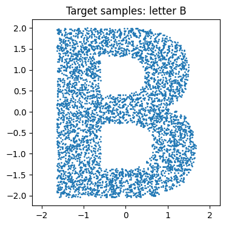

```
step 5000: loss 3.236
step 10000: loss 3.244
step 15000: loss 3.234
step 20000: loss 3.232
step 25000: loss 3.225
step 30000: loss 3.229
Training time: 40.0 s
```

**Task 1.** Target: the letter "B", which I drew with matplotlib's bundled bold font, so no external images and no usage permissions are needed. Each target point is a random pixel inside the letter plus a small random shift within that pixel, then centered and scaled so the letter spans −2 to 2 vertically.

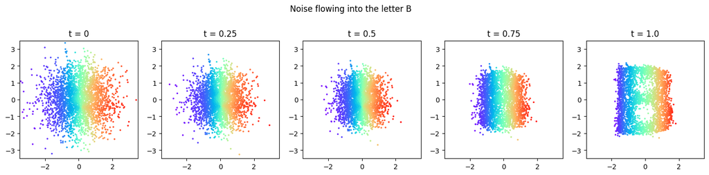

**Task 2.** The same 3,000 particles are tracked through all 100 steps. Each particle's color is set by where it ends up (its final x-position, rainbow colormap) and kept the whole way. Colors are only for visualization: they are not part of training, and the network only predicts 2D velocities.

[figure not shown]

Animation link: https://batorgil7.github.io/deep-learning/Project2/letter_B_flow.gif

```
Best possible (B vs. B): 0.089

steps  network calls  time (ms)  hist diff
    1              1       15.2      0.980
    5              5       68.0      0.271
   10             10      148.3      0.186
   25             25      348.6      0.161
   50             50      715.8      0.153
  100            100     1417.9      0.151
```

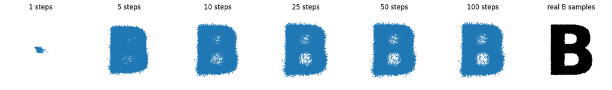

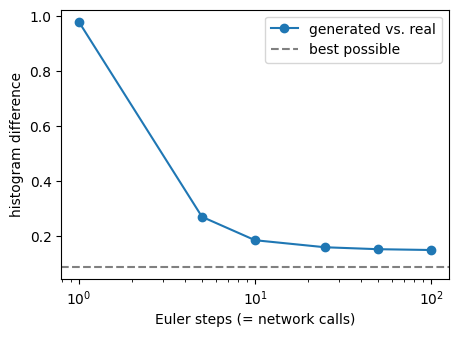

Task 3. With the same weights and starting noise, 1 step gives a blob: every dot moves once using the velocity at t = 0, which is only an average direction. Quality improves quickly up to about 25 steps, then levels off around 0.15, while the best possible score (two real B samples) is about 0.09. Sampling time grows in proportion to the number of steps, since each step is one network call. The gap that remains after leveling off is not caused by too few steps. It comes from the learned model (blurry edges, points between strokes) and the target representation (pixel grid, 40×40 histogram), and more steps can't fix an inaccurate model.

# Part 3: Does Reflow Straighten the Paths?

Hypothesis: One round of reflow will make the sampling paths straighter, so with very few steps (1–5) the dots will land closer to the B than the baseline, while quality at many steps stays about the same.

```
Made 50000 pairs in 3.7 s
```

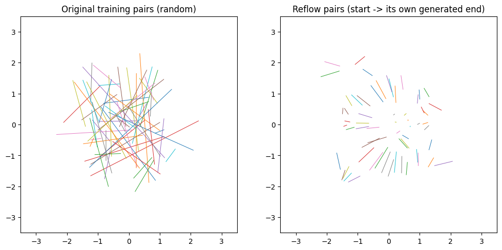

```
Reflow extra cost: making pairs 3.7 s + training 5.6 s = 9.3 s
Compute-matched baseline extra training: 5.7 s
```

```
Histogram difference (lower = better). Best possible ~ 0.091
steps      baseline   baseline+6k        reflow
    1         0.979         0.968         0.173
    2         0.642         0.673         0.160
    5         0.277         0.300         0.156
   10         0.190         0.205         0.156
   25         0.157         0.168         0.156
   50         0.154         0.161         0.155
  100         0.152         0.158         0.155

Sampling time (ms) = network calls x time per call
steps      baseline   baseline+6k        reflow
    1          13.8          15.8          13.5
    2          29.1          32.1          27.9
    5          78.5          72.1          71.5
   10         145.6         142.2         144.1
   25         363.3         360.5         397.3
   50         712.6         741.9         821.8
  100        1666.6        1443.6        1989.9

Straightness (200-step grid):
      baseline: 0.5103
   baseline+6k: 0.5247
        reflow: 0.0001
```

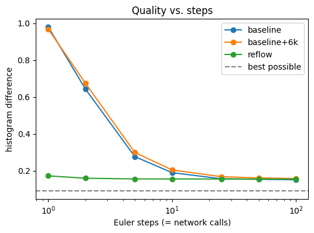

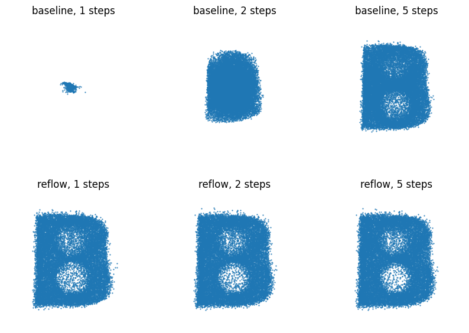

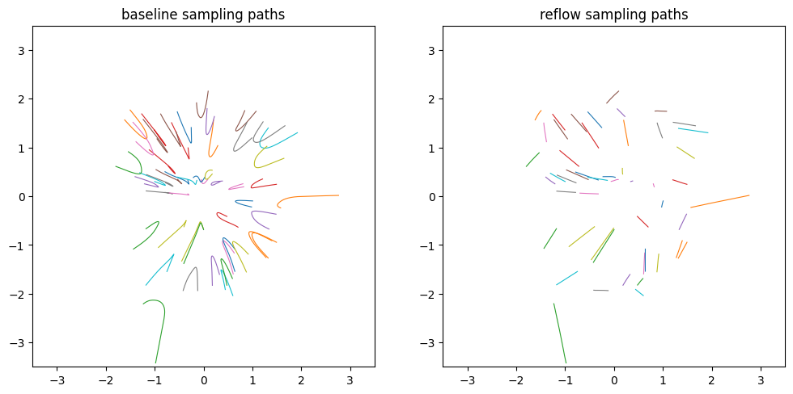

```
--- seed 1 ---
step 5000: loss 3.263
step 10000: loss 3.241
step 15000: loss 3.237
step 20000: loss 3.236
step 25000: loss 3.220
step 30000: loss 3.205
Training time: 30.8 s
--- seed 2 ---
step 5000: loss 3.256
step 10000: loss 3.249
step 15000: loss 3.242
step 20000: loss 3.219
step 25000: loss 3.225
step 30000: loss 3.217
Training time: 32.2 s

Mean ± std over 3 seeds (histogram difference, lower = better)
       model            1 step            2 step            5 step           25 step      straightness
    baseline   0.9776 ± 0.0083   0.6471 ± 0.0143   0.2825 ± 0.0040   0.1673 ± 0.0078   0.5144 ± 0.0174
 baseline+6k   0.9765 ± 0.0077   0.6551 ± 0.0202   0.2885 ± 0.0093   0.1639 ± 0.0031   0.5142 ± 0.0089
      reflow   0.1786 ± 0.0043   0.1685 ± 0.0067   0.1637 ± 0.0058   0.1633 ± 0.0059   0.0001 ± 0.0000
```

## Part 3, Task 3: What the evidence supports

**Alternative explanation: extra training.** The reflow model got 6,000 more training steps than the baseline. To rule this out, I trained a compute-matched baseline for the same 6,000 extra steps on the original random pairs. It did not improve (0.977 at 1 step, straightness 0.51), so the gain comes from the paired data, not extra training.

**Straighter is not the same as more accurate.** At 25 steps, all three models score about 0.163–0.167, with differences inside seed noise. Reflow did not make the final shape better; it made the same shape reachable in fewer steps. All models stay well above the best possible score (about 0.091, two independent samples of the true B), so the remaining error comes from the learned model, not from the number of steps.

**Inherited errors.** Reflow learns from the baseline's generated endpoints, not from the true B. Any mistakes the baseline makes (blurry edges, points between the letter's strokes) are copied into the reflow training data, so reflow cannot be more accurate than the baseline it learned from.

**Cost.** Reflow needed 9.3 s of one-time extra work (3.7 s to generate 50,000 pairs + 5.6 s training). This is paid once, while the savings apply to every later sample.

**Limits.** Only 3 seeds, one target shape (the letter B), one round of reflow, and one quality metric (a 40x40 histogram, which can miss fine details). The held-out test noise was never used to build the reflow pairs.

```
CPU: 13th Gen Intel(R) Core(TM) i7-1355U
OS: Linux-6.18.33.2-microsoft-standard-WSL2-x86_64-with-glibc2.43
Threads used: 2 | GPU: none (CPU only)
Python 3.9.25 | torch 2.0.0+cu117 | numpy 1.23.5 | matplotlib 3.7.2
```

## Setup and reproducibility

| Item | Value |
| --- | --- |
| Model | MLP: input (x, y, t) → 128 → 128 → 128 → 2, SiLU activations, 33,794 parameters |
| Training | Adam, learning rate 1e-3, batch 256, 30,000 steps (31-40 s) |
| Target | Letter "B" drawn with matplotlib (bold font) on a 200×200 image; points = random letter pixels + uniform jitter, scaled so the letter spans −2 to 2 vertically |
| Reflow | 50,000 pairs made with 100 Euler steps (3.7 s); reflow model = copy of baseline + 6,000 steps on pairs (5.6 s) |
| Compute-matched baseline | copy of baseline + 6,000 steps on original random pairs (5.7 s) |
| Quality metric | 40×40 histogram on [−3, 3]², plus one extra bin for points outside; score = half the summed absolute difference |
| Seeds | training 0 (plus 1 and 2 for the seed check), animation noise 1, step comparison 123, reflow pairs 2026, held-out test 999 |